# Practical Machine Learning: Peer-Graded Assignment

Elke Klaassen

24-2-2020

## Environment setup

```r
library(dplyr)
library(caret)
library(rattle)
library(randomForest)
```

## Introduction

This report explains the steps taken to build a prediction model to predict how well a particalur activity is performed. The variable that we want to predict is called **classe** and can be either *A, B, C, D, E*. The dataset, and more information about the related research can be found on this page: http://web.archive.org/web/20161224072740/http:/groupware.les.inf.puc-rio.br/har.

## Data exploration

```r
trainingdata <- read.csv("Data//pml-training.csv", header=T)
testingdata <- read.csv("Data//pml-testing.csv", header=T)

# dim(trainingdata)
# dim(testingdata)

# head(trainingdata)
# str(trainingdata)
# summary(trainingdata)

trainingset <- trainingdata[, colSums(is.na(trainingdata)) == 0]
testingset <- testingdata[, colSums(is.na(testingdata)) == 0]

# dim(trainingset)
# dim(testingset)
```

The data initially consisted of 19622 rows and 160 variables (incl. **classe**, i.e. the y variable). Based on data exploration, the first step taken was to remove the `NA` values. It can be observed that the testing dataset only has 60 columns left. The goal is to predict the `classe` for the testing dataset, therefore we focus only on the columns available in the testing dataset. Furthermore, we do not focus on the first seven columns, as these are not considered relevant to make predictions (they do not include sensor values).

```r
trainingset <- trainingset[, which(colnames(trainingset) %in% c(colnames(testingset), 'classe'))]

colNotInTrain <- colnames(testingset)[!(colnames(testingset) == colnames(trainingset))]
colNotInTest <- colnames(trainingset)[!(colnames(trainingset) == colnames(testingset))]

# remove first 7 columns
trainingset <- trainingset[, -c(1:7)]
testingset <- testingset[, -c(1:7)]

# make sure the testing set consists of the same columns
testingset <- testingset[, !(colnames(testingset)==colNotInTrain)]

# check the distribution of y var
# ggplot(trainingset, aes(x=classe)) + geom_bar()
```

## 1st Predicition model: Regression Tree

This sections shows the results of the Regression Tree model. First the data is split into a training and test dataset and the train control method is based on cross validation (4-fold). Before the variables are considered in the model, they are first checked for near zero variance. If they are not near zero varianced, the variables are included in the model.

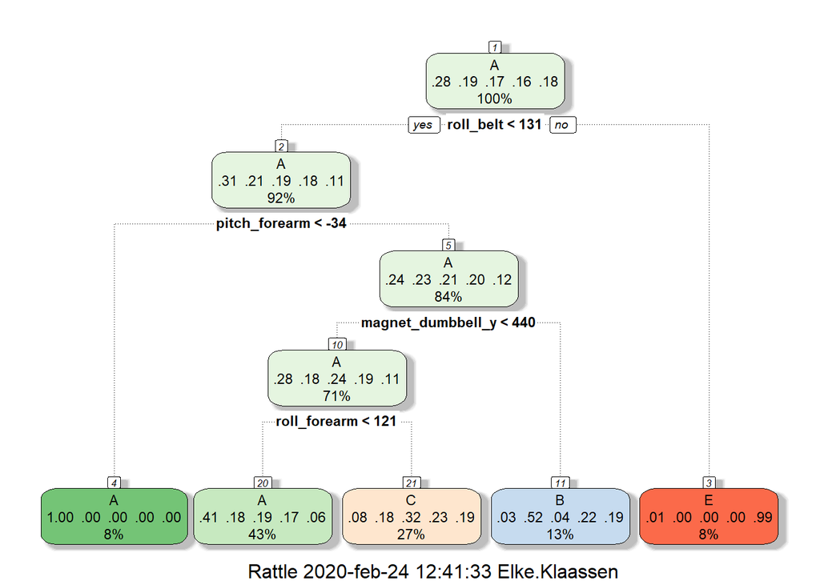

```r
# Check for variables that have near zero variance
nsv <- nearZeroVar(trainingset, saveMetrics=TRUE)
# All seem okay, for now stick w/ all variables in the model

# Create a subset for training and testing
inTrain <- createDataPartition(y=trainingset$classe, p=.6, list=FALSE)
training <- trainingset[inTrain, ]
testing <- trainingset[-inTrain, ]

# Configure the train control for cross-validation
tc = trainControl(method = "cv", number = 4)

# Fit the model
modFit1 <- train(classe ~.,
                data = training,
                method="rpart",
                trControl = tc)
# print(modFit$finalModel)
fancyRpartPlot(modFit1$finalModel)
```

```r
predictions <- predict(modFit1, newdata=testing)
confusionMat <- confusionMatrix(predictions, testing$classe)
confusionMat$table
```

```
##           Reference
## Prediction    A    B    C    D    E
##          A 2016  624  631  567  232
##          B   33  495   45  240  193
##          C  175  399  692  479  362
##          D    0    0    0    0    0
##          E    8    0    0    0  655
```

```r
confusionMat$overall[1]
```

```
##  Accuracy
## 0.4917155
```

Based on the above results of the Regression Tree, it is concluded that the model is not performing well (accuracy ~ 0.4917155). Therefore, another model is will be used.

## 2nd Predicition model: Random Forest

The same train and test dataset, as well as train control method is used as specified above (for the Regression Tree model).

```r
# NOTE: Same subsets and train control method as above is used!

# Fit the model
modFit2 <- train(classe ~.,
                data = training,
                method="rf",
                trControl = tc,
                prox = TRUE,
                allowParallel = TRUE)
# modFit2$finalModel

predictions <- predict(modFit2, newdata=testing)
confusionMat <- confusionMatrix(predictions, testing$classe)
confusionMat$table
```

```
##           Reference
## Prediction    A    B    C    D    E
##          A 2228   24    0    0    0
##          B    1 1488    9    1    1
##          C    2    6 1356   25    2
##          D    0    0    3 1253    7
##          E    1    0    0    7 1432
```

```r
confusionMat$overall[1]
```

```
##  Accuracy
## 0.9886566
```

```r
head(varImp(modFit2))
```

```
## $importance
##                          Overall
## roll_belt            100.0000000
## pitch_belt            44.8178900
## yaw_belt              53.9025097
## total_accel_belt       2.1015607
## gyros_belt_x           1.2990038
## gyros_belt_y           1.7406742
## gyros_belt_z          10.1355502
## accel_belt_x           0.6982022
## accel_belt_y           1.0528272
## accel_belt_z          13.6774882
## magnet_belt_x         10.4818667
## magnet_belt_y         13.3533932
## magnet_belt_z         15.0171565
## roll_arm               8.2705301
## pitch_arm              3.9430333
## yaw_arm               10.1869984
## total_accel_arm        1.4876579
## gyros_arm_x            2.3632246
## gyros_arm_y            3.6038346
## gyros_arm_z            0.0000000
## accel_arm_x            5.5665716
## accel_arm_y            3.5132970
## accel_arm_z            1.9994242
## magnet_arm_x           5.4845075
## magnet_arm_y           4.9905486
## magnet_arm_z           4.4191051
## roll_dumbbell         16.7581958
## pitch_dumbbell         3.4232599
## yaw_dumbbell           8.3547122
## total_accel_dumbbell  14.1020968
## gyros_dumbbell_x       3.1365847
## gyros_dumbbell_y       7.3912431
## gyros_dumbbell_z       1.0451882
## accel_dumbbell_x       6.0659580
## accel_dumbbell_y      22.0281439
## accel_dumbbell_z      13.1922441
## magnet_dumbbell_x     16.4044619
## magnet_dumbbell_y     45.3040313
## magnet_dumbbell_z     45.8449122
## roll_forearm          43.1945499
## pitch_forearm         59.4235391
## yaw_forearm            6.6483334
## total_accel_forearm    1.7117089
## gyros_forearm_x        0.1114378
## gyros_forearm_y        1.9643635
## gyros_forearm_z        1.1549637
## accel_forearm_x       17.3146853
## accel_forearm_y        3.4067671
## accel_forearm_z        7.3502606
## magnet_forearm_x       5.5052638
## magnet_forearm_y       6.6274453
## magnet_forearm_z      14.0224516
##
## $model
## [1] "rf"
##
## $calledFrom
## [1] "varImp"
```

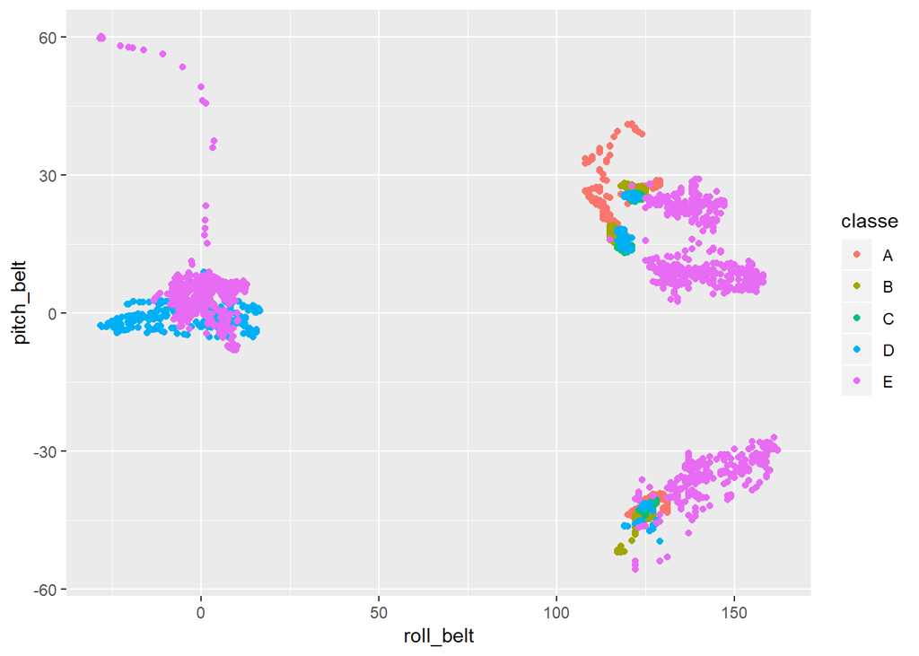

```r
# roll_belt + pitch_belt are the most important variables in the random forest mdl

qplot(roll_belt, pitch_belt, color=classe, data=testing)
```

## Make the final predictions

```r
finalPredictions <- predict(modFit2, newdata=testingset)
write.csv(as.data.frame(finalPredictions), file = "Results\\finalPredictions.csv", row.names = TRUE)
```